# Discussion 7

Dmitriy Izyumin

February 22, 2017

### ARIMA(p,d,q) models

In his textbook Rob Hyndman provides the following guide for fitting ARIMA models to data.

1. Plot the data. Identify any unusual observations.
2. If necessary, transform the data (using a Box-Cox transformation) to stabilize the variance.
3. If the data are non-stationary: take first differences of the data until the data are stationary.
4. Examine the ACF/PACF: Is an AR(p) or MA(q) model appropriate?
5. Try your chosen model(s), and use the AICc to search for a better model.
6. Check the residuals from your chosen model by plotting the ACF of the residuals, and doing a portmanteau test of the residuals. If they do not look like white noise, try a modified model.
7. Once the residuals look like white noise, calculate forecasts.

We’ll use Hyndman’s `forecast` package to work with ARIMA models. Install the package if you haven’t installed it before (use `install.packages()`).

```r
library(forecast)
```

I recommend reading the manual and getting familiar with the package. Here are just a few useful functions in it:

- The functions `Acf()` and `Pacf()` are slight improvements over `acf()` and `pacf()`.
- The function `Arima()` can be used to fit a model with specified values of $d$, $p$ and $q$ to data.
- The function `auto.arima()` selects $d$, $p$ and $q$ using a stepwise search. A model using the chosen values is then fit to the data.
- The function `BoxCox.lambda()` can be used to select $\lambda$ for a Box-Cox transformation of the data. The function `BoxCox()` can be used to transform the data using a selected value of $\lambda$.
- The function `forecast()` can compute forecasts and prediction intervals from ARIMA objects in R. An ARIMA object is the output of functions like `arima()`, `Arima()`, `auto.arima()`, and others.
- The function `ndiffs()` uses unit root tests to determine the number of differences required to mae a given time series stationary.

### Example 1 - Simulated Data

Let’s generate some data to work with.

```r
set.seed(317)

# white noise
w = arima.sim(n=100, model=list())

# AR(1)
x1 = arima.sim(n=100, model=list(ar=c(-0.3)))

# MA(1)
x2 = arima.sim(n=100, model=list(ma=c(0.2)))

# ARMA(1,1)
x3 = arima.sim(n=100, model=list(ar=c(-0.3), ma=c(0.2)))

# ARIMA(1,1,0)
x4 = arima.sim(n=100, model=list(ar=c(-0.3), order=c(1,1,0)))

# ARIMA(1,1,1)
x5 = arima.sim(n=100, model=list(ar=c(-0.3), ma=c(0.2), order=c(1,1,1)))
```

1. Let’s plot the data. Which data sets look stationary?

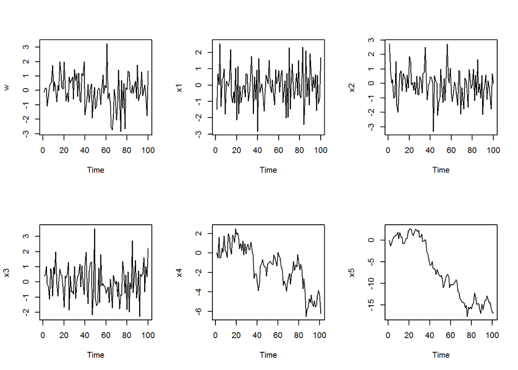

```r
par(mfrow = c(2,3))
ts.plot(w)
ts.plot(x1)
ts.plot(x2)
ts.plot(x3)
ts.plot(x4)
ts.plot(x5)
```

2. For this example tranformations aren’t necessary.
3. The last two data sets are clearly not stationary. Let’s use the `ndiffs()` function to check how many differences would make each data set roughly stationary.

```r
ndiffs(w)
```

```
## [1] 0
```

```r
ndiffs(x1)
```

```
## [1] 0
```

```r
ndiffs(x2)
```

```
## [1] 0
```

```r
ndiffs(x3)
```

```
## [1] 0
```

```r
ndiffs(x4)
```

```
## [1] 1
```

```r
ndiffs(x5)
```

```
## [1] 1
```

4. Here are the ACF and PACF plots of the first four data sets. Based on these plots, what ARMA(p,q) models might you select?

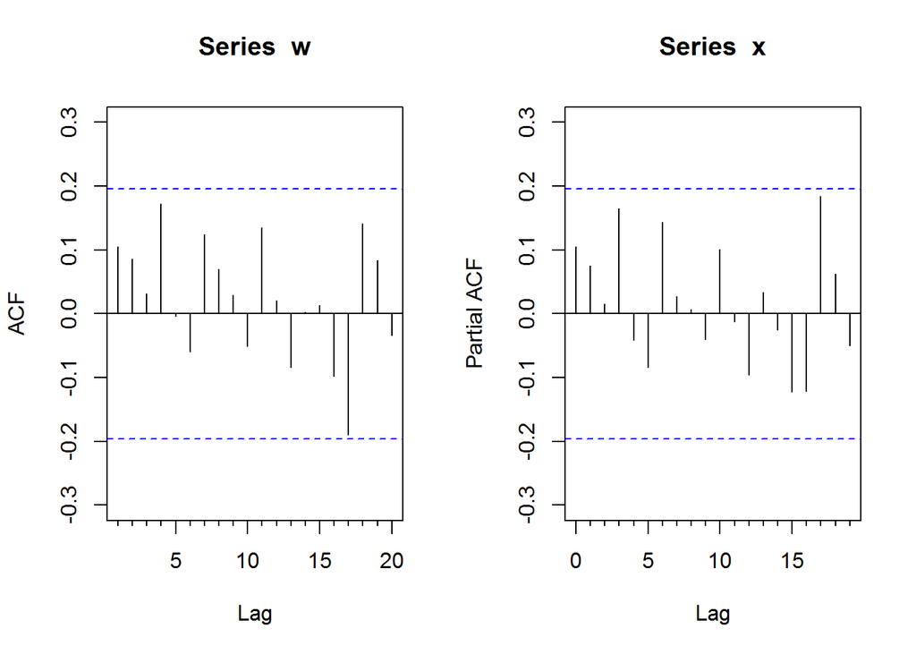

```r
par(mfrow = c(1,2))
Acf(w); Pacf(w)
```

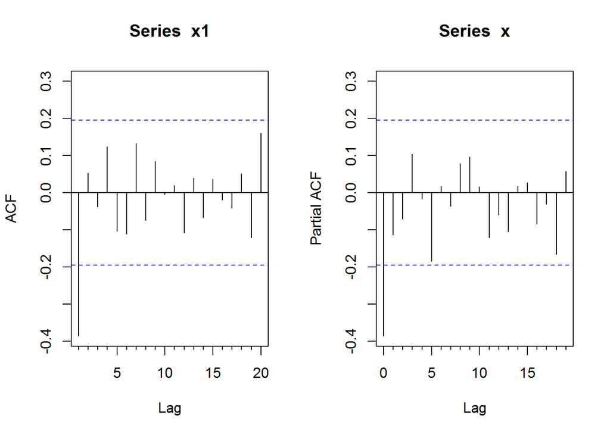

```r
Acf(x1); Pacf(x1)
```

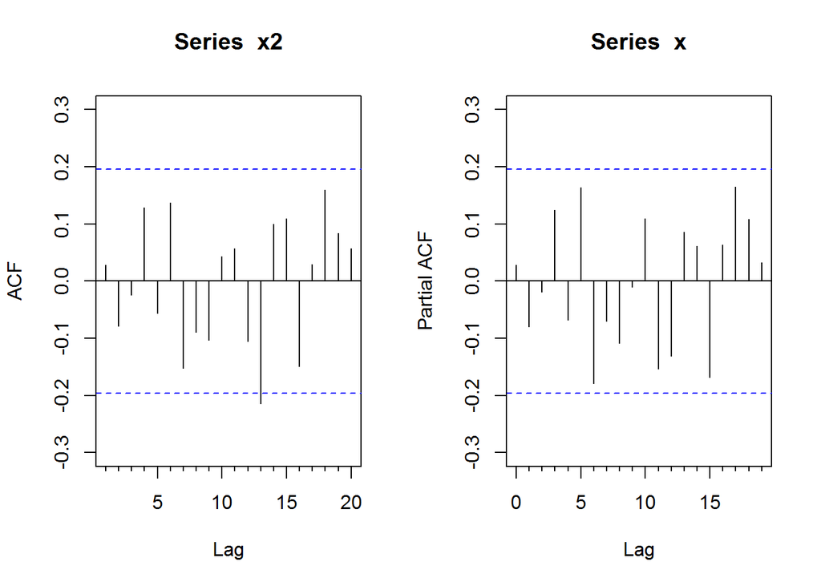

```r
Acf(x2); Pacf(x2)
```

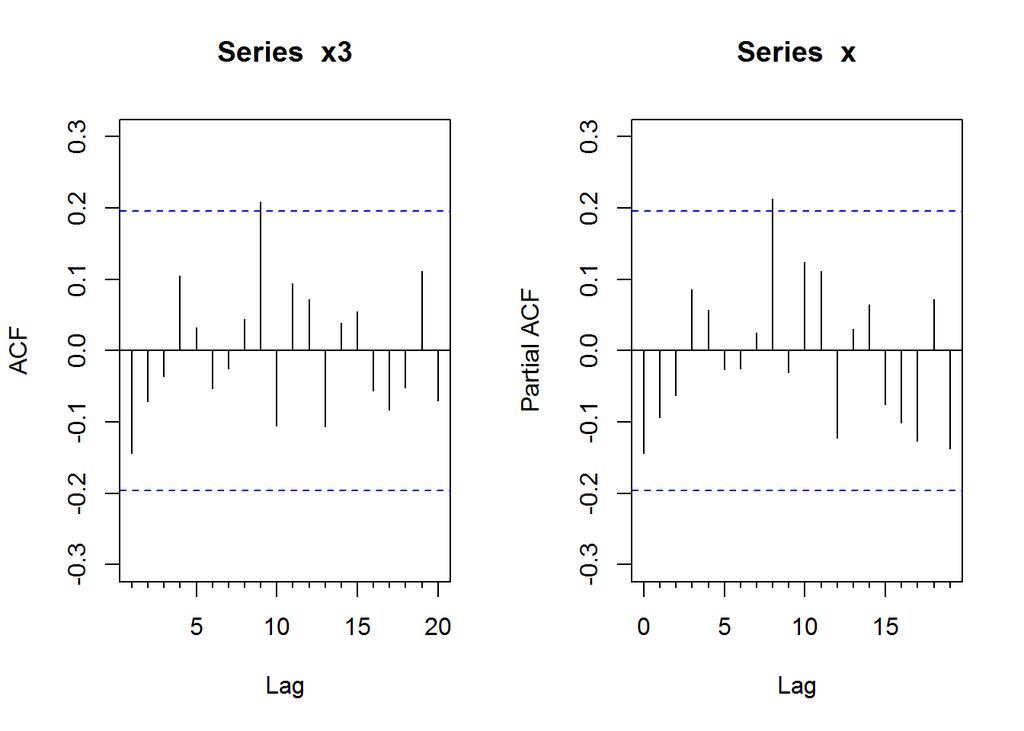

```r
Acf(x3); Pacf(x3)
```

Now let’s take a look at the ACF and PACF plots of the last two data sets before and after differencing.

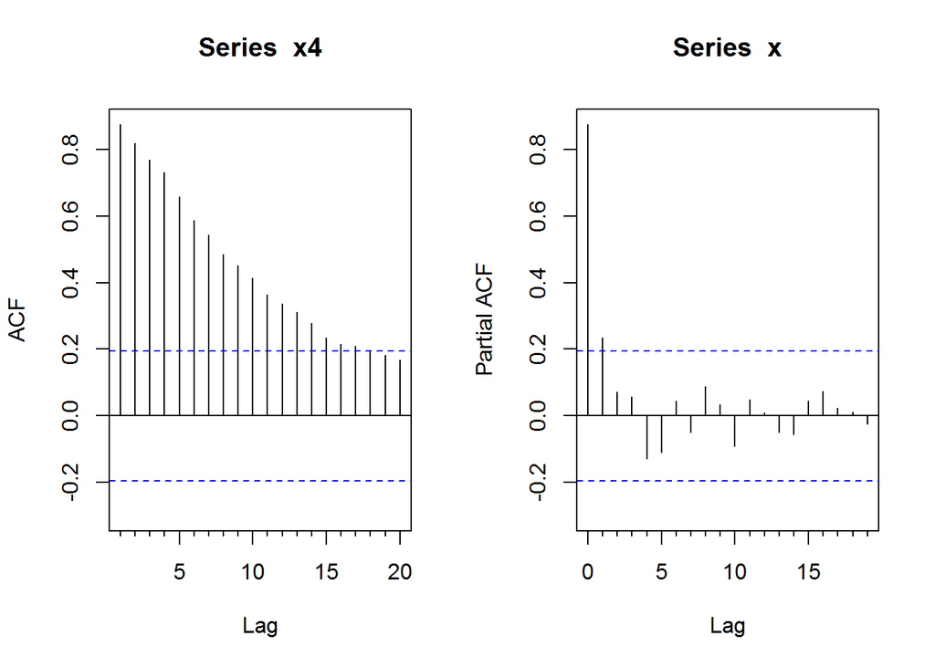

```r
par(mfrow = c(1,2))

Acf(x4); Pacf(x4)
```

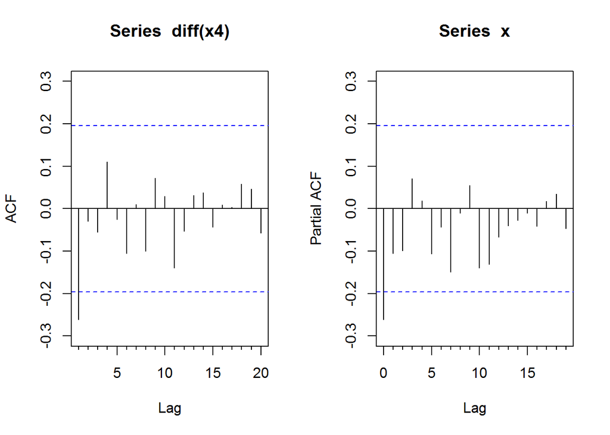

```r
Acf(diff(x4)); Pacf(diff(x4))
```

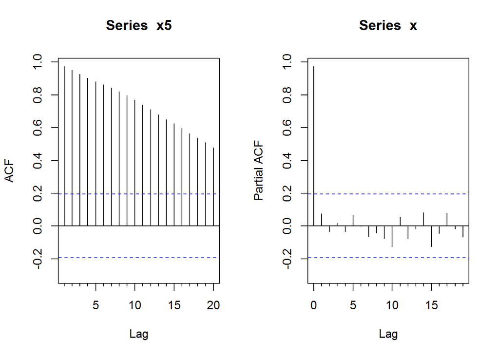

```r
Acf(x5); Pacf(x5)
```

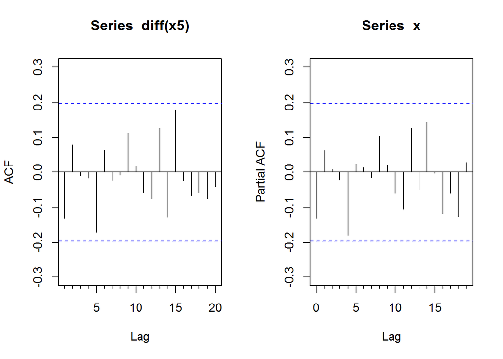

```r
Acf(diff(x5)); Pacf(diff(x5))
```

5. Based on the ACF and PACF plots, an ARIMA(1,1,0) model seems appropriate for `x4`. First, let’s use `Arima()`. Take a look at what the command prints out by default, and what other information is contained in the output.

```r
fit1 = Arima(x4, order=c(1,1,0))
fit1
```

```
## Series: x4
## ARIMA(1,1,0)
##
## Coefficients:
##           ar1
##       -0.2645
## s.e.   0.0978
##
## sigma^2 estimated as 0.8801:  log likelihood=-135.04
## AIC=274.08   AICc=274.2   BIC=279.29
```

```r
names(fit1)
```

```
##  [1] "coef"      "sigma2"    "var.coef"  "mask"      "loglik"
##  [6] "aic"       "arma"      "residuals" "call"      "series"
## [11] "code"      "n.cond"    "nobs"      "model"     "aicc"
## [16] "bic"       "x"
```

```r
summary(fit1)
```

```
## Series: x4
## ARIMA(1,1,0)
##
## Coefficients:
##           ar1
##       -0.2645
## s.e.   0.0978
##
## sigma^2 estimated as 0.8801:  log likelihood=-135.04
## AIC=274.08   AICc=274.2   BIC=279.29
##
## Training set error measures:
##                       ME      RMSE       MAE      MPE     MAPE     MASE
## Training set -0.07259122 0.9287817 0.7299332 28.00404 119.9003 0.937705
##                     ACF1
## Training set -0.03398588
```

Now let’s use the `auto.arima()` function to choose the order of the model, and fit it.

```r
fit2 = auto.arima(x4)
fit2
```

```
## Series: x4
## ARIMA(0,1,1)
##
## Coefficients:
##           ma1
##       -0.3120
## s.e.   0.0997
##
## sigma^2 estimated as 0.8683:  log likelihood=-134.38
## AIC=272.76   AICc=272.88   BIC=277.97
```

```r
names(fit2)
```

```
##  [1] "coef"      "sigma2"    "var.coef"  "mask"      "loglik"
##  [6] "aic"       "arma"      "residuals" "call"      "series"
## [11] "code"      "n.cond"    "nobs"      "model"     "bic"
## [16] "aicc"      "x"
```

```r
summary(fit2)
```

```
## Series: x4
## ARIMA(0,1,1)
##
## Coefficients:
##           ma1
##       -0.3120
## s.e.   0.0997
##
## sigma^2 estimated as 0.8683:  log likelihood=-134.38
## AIC=272.76   AICc=272.88   BIC=277.97
##
## Training set error measures:
##                      ME      RMSE       MAE      MPE     MAPE      MASE
## Training set -0.0802714 0.9225429 0.7227208 28.65365 118.6316 0.9284397
##                    ACF1
## Training set 0.00237648
```

Notice that this command selected an ARIMA(0,1,1) model instead of the ARIMA(1,1,0) model suggested by the sample ACF and PACF plots. This is because the selection is based on AICc, and the former model has a slightly lower value of the criterion.

6. Now let’s inspect the residuals of both models. Ideally, they should resemble Gaussian white noise.

```r
res1 = fit1$res

par(mfrow=c(2, 2))
ts.plot(res1)
Acf(res1); Pacf(res1)

Box.test(res1, lag=10, type="Ljung")
```

```
##
##  Box-Ljung test
##
## data:  res1
## X-squared = 6.7066, df = 10, p-value = 0.7528
```

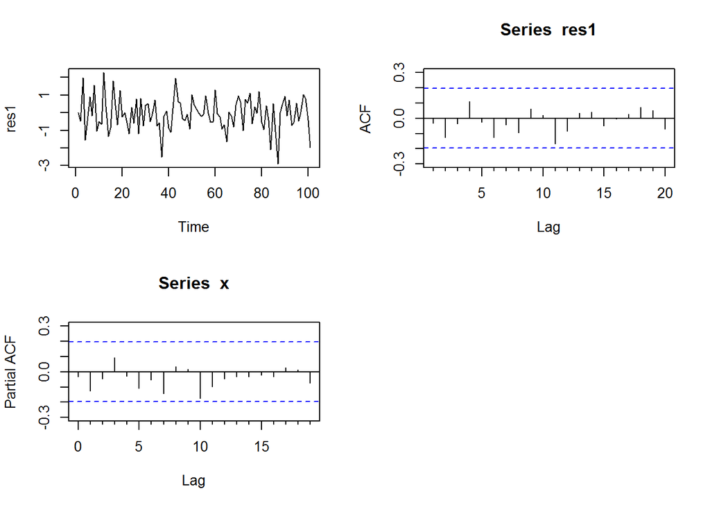

```r
par(mfrow=c(1,2))
```

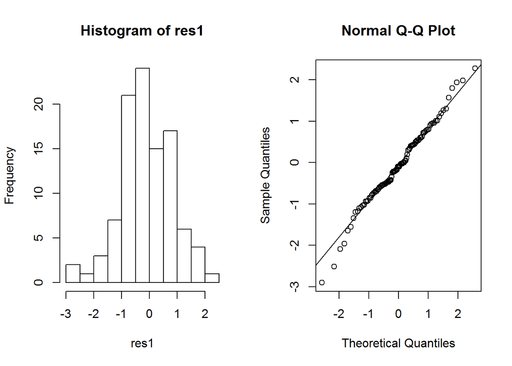

```r
hist(res1)
qqnorm(res1); qqline(res1)
```

Second model (ARIMA(0,1,1)):

```r
res2 = fit2$res

par(mfrow=c(2, 2))
ts.plot(res2)
Acf(res2); Pacf(res2)

Box.test(res2, lag=10, type="Ljung")
```

```
##
##  Box-Ljung test
##
## data:  res2
## X-squared = 5.1096, df = 10, p-value = 0.8837
```

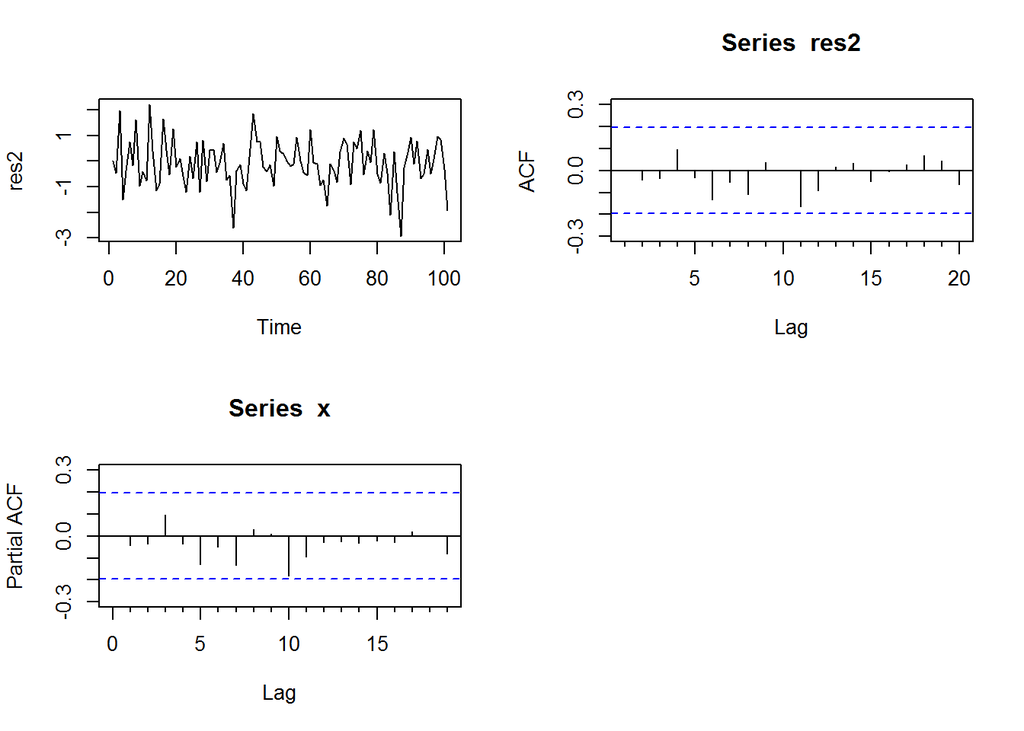

```r
par(mfrow=c(1,2))
```

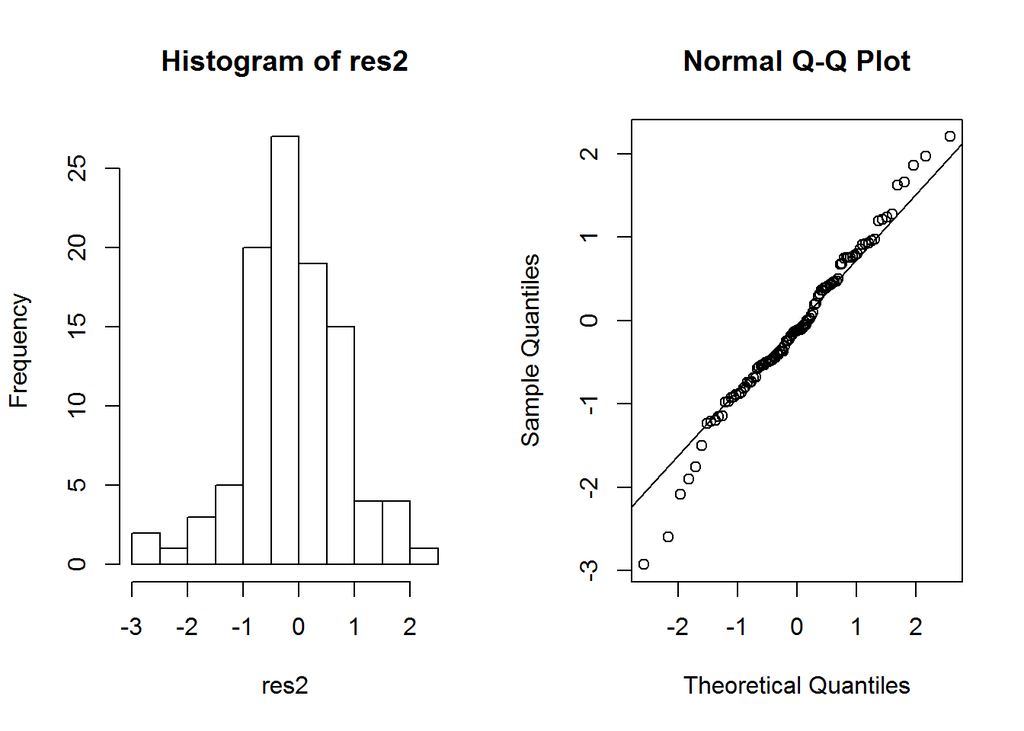

```r
hist(res2)
qqnorm(res2); qqline(res2)
```

7. Let’s use the second model to compute forecasts of `x4`.

The command below computes point forecasts $h=10$ steps ahead, along with bounds for $80\%$, $90\%$ and $95\%$ prediction intervals.

```r
forecast(fit2, h=10, level=c(80, 90, 95))
```

```
##     Point Forecast     Lo 80     Hi 80     Lo 90     Hi 90     Lo 95
## 102      -5.596104 -6.790273 -4.401935 -7.128803 -4.063405 -7.422428
## 103      -5.596104 -7.045590 -4.146618 -7.456500 -3.735709 -7.812902
## 104      -5.596104 -7.262232 -3.929977 -7.734556 -3.457653 -8.144226
## 105      -5.596104 -7.453778 -3.738431 -7.980402 -3.211806 -8.437171
## 106      -5.596104 -7.627341 -3.564868 -8.203168 -2.989040 -8.702612
## 107      -5.596104 -7.787198 -3.405010 -8.408343 -2.783866 -8.947093
## 108      -5.596104 -7.936160 -3.256048 -8.599534 -2.592675 -9.174911
## 109      -5.596104 -8.076192 -3.116017 -8.779262 -2.412947 -9.389071
## 110      -5.596104 -8.208728 -2.983480 -8.949371 -2.242838 -9.591768
## 111      -5.596104 -8.334858 -2.857350 -9.111257 -2.080951 -9.784667
##         Hi 95
## 102 -3.769781
## 103 -3.379307
## 104 -3.047982
## 105 -2.755038
## 106 -2.489596
## 107 -2.245115
## 108 -2.017297
## 109 -1.803138
## 110 -1.600441
## 111 -1.407541
```

The `forecast` package also works well with the `plot()` function. Take a look at what happens when I place the previous command as an argument to `plot()`.

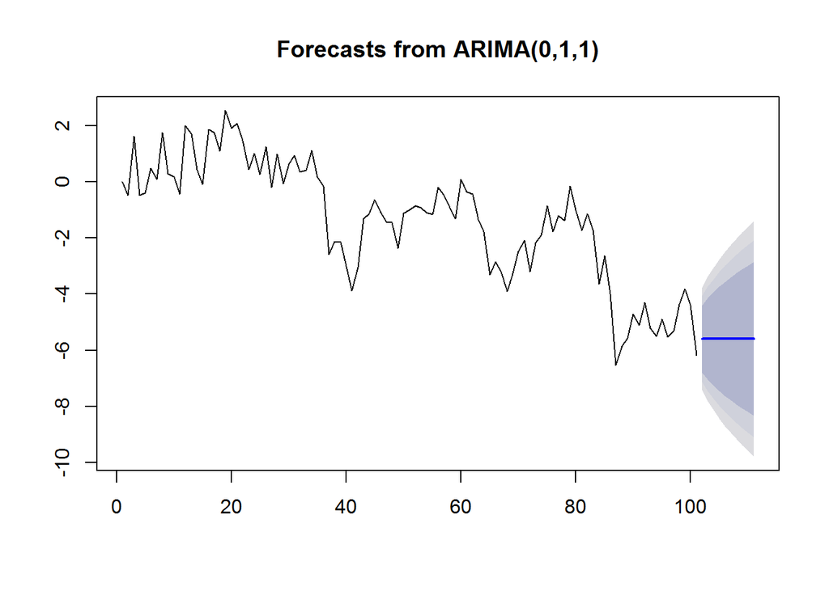

```r
plot(forecast(fit2, h=10, level=c(80, 90, 95)))
```

### Example 2 - Temperature Data

```r
temp = read.table("datasets/globTemp.txt", header=T)
y = temp[,2]
```

Based on preliminary plots, the data clearly is not mean-stationary.

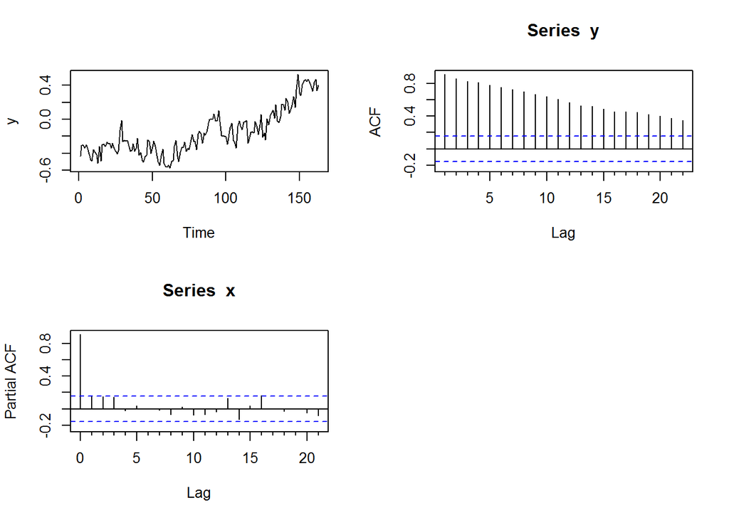

```r
par(mfrow=c(2,2))
ts.plot(y)
Acf(y); Pacf(y)
```

The function `ndiffs()` suggests taking one difference. The differenced series appear stationary, but the ACF and PACF plots do not reveal a clear choice of model.

```r
ndiffs(y)
```

```
## [1] 1
```

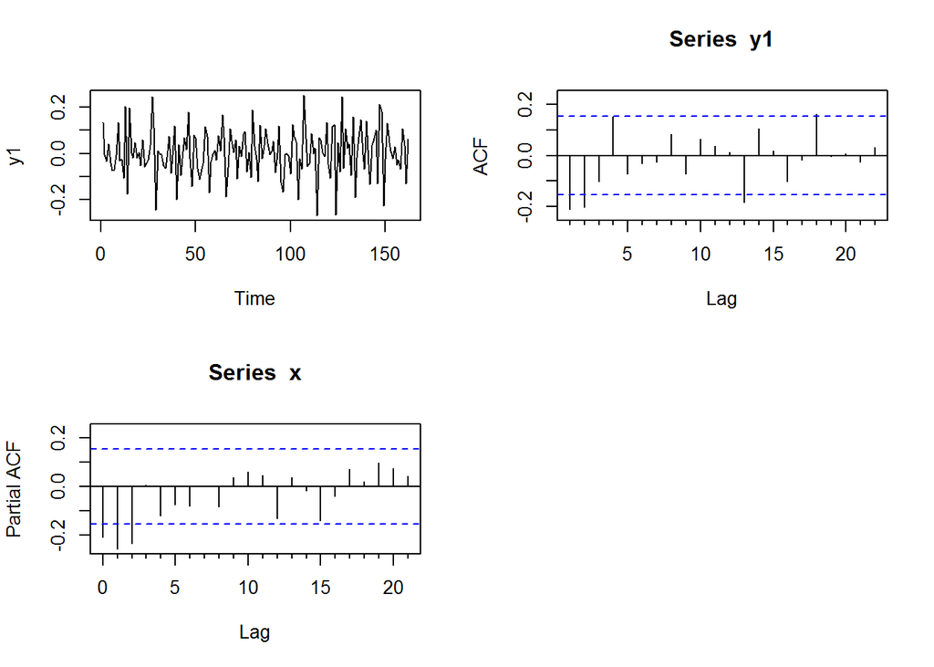

```r
y1 = diff(y)

par(mfrow=c(2,2))
ts.plot(y1)
Acf(y1); Pacf(y1)
```

```r
fit = auto.arima(y); fit
```

```
## Series: y
## ARIMA(0,1,2) with drift
##
## Coefficients:
##           ma1      ma2   drift
##       -0.3740  -0.2402  0.0049
## s.e.   0.0726   0.0692  0.0028
##
## sigma^2 estimated as 0.008728:  log likelihood=155.49
## AIC=-302.98   AICc=-302.72   BIC=-290.63
```

The residuals of this model look roughly like Gaussian white noise.

```r
res = fit$res

par(mfrow=c(2, 2))
ts.plot(res)
Acf(res); Pacf(res)

Box.test(res, lag=10, type="Ljung")
```

```
##
##  Box-Ljung test
##
## data:  res
## X-squared = 6.6887, df = 10, p-value = 0.7545
```

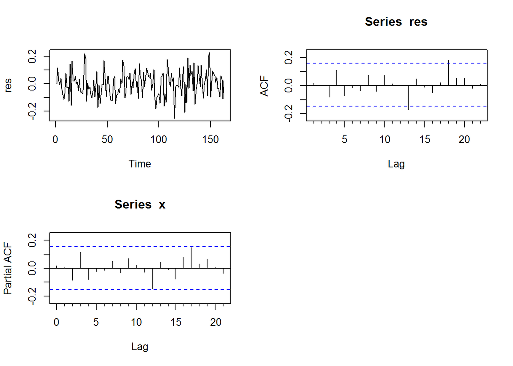

```r
par(mfrow=c(1,2))
```

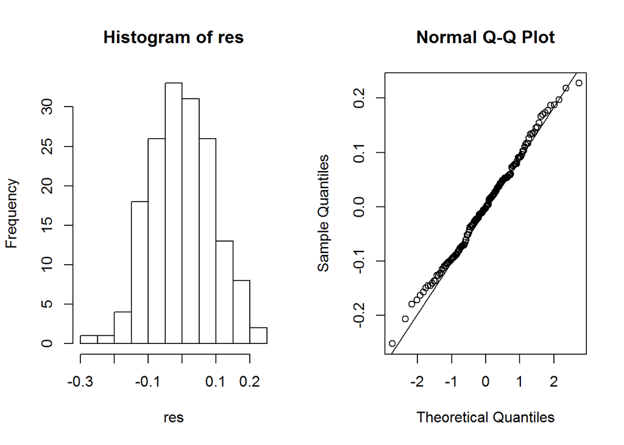

```r
hist(res)
qqnorm(res); qqline(res)
```

We can now compute point and interval forecasts.

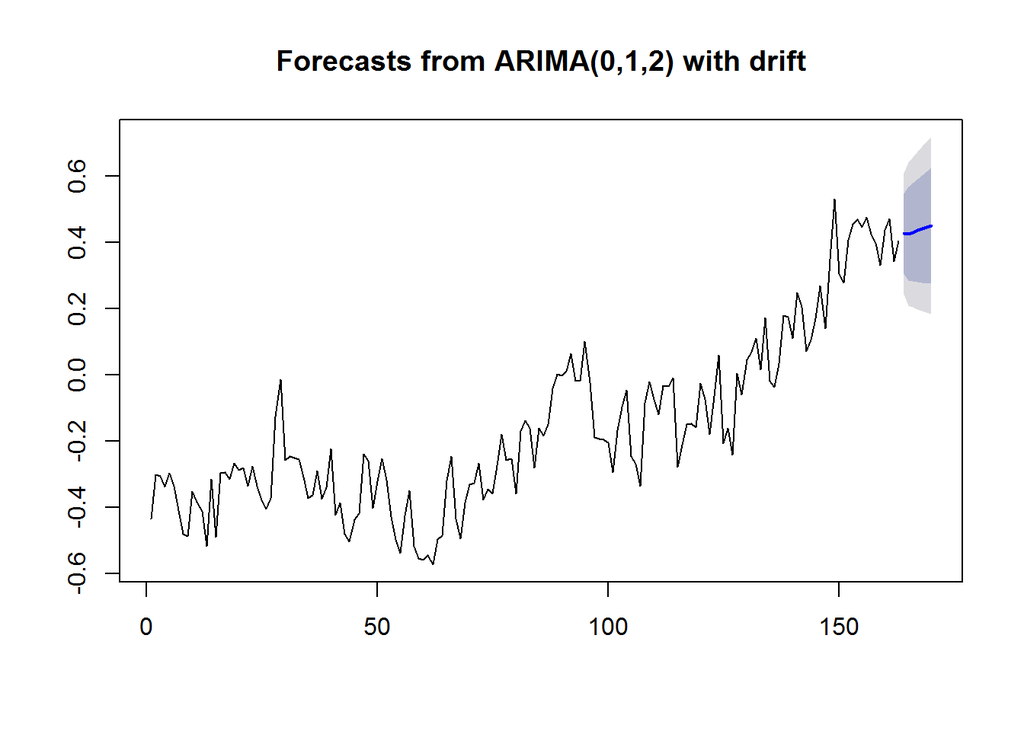

```r
plot(forecast(fit, h=7, level=c(80, 95)))
```